# Ensemble Multiple Linear Regression

DA5030

Zoe Chow

Summer 2025

#### *The goal of this project is to build an ensemble model that combines three linear regression models to predict the target variable.*

## Load Packages and CSV

```r
library(dplyr)
library(kableExtra)
library(knitr)
library(psych)
library(caret)
```

```r
train_url <- "https://s3.us-east-2.amazonaws.com/artificium.us/datasets/synth-data.csv"
df <- read.csv(train_url, stringsAsFactors = F, header = T)
```

## Data Preparation

Linear regression models are sensitive to noisy data and require numeric features. Therefore, we will need to handle missing values and outliers, as well as encode characterized categorical data. We will also visualize the distribution of the data to ensure normality. If the data is not normally distributed, we will perform log and square root transformations on the data.

### Exploratory Data Analysis (EDA)

```r
head(df)
```

|  | X | N1 | N2 | B1 | C1 | N3 | N4 | N5 | N6 | Target |
| --- | --- | --- | --- | --- | --- | --- | --- | --- | --- | --- |
| 1 | 1 | 54.96714 | 16.82366 | False | Level4 | 2.113105732 | 1 | 15 | 34.01712 | 179.4131 |
| 2 | 2 | 48.61736 | 18.99347 | False | Level3 | 2.153364870 | 1 | 12 | 29.66952 | 163.2710 |
| 3 | 3 | 56.47689 | 46.07122 | True | Level1 | 3.915496313 | 3 | 12 | 32.21371 | 223.6947 |
| 4 | 4 | 65.23030 | 28.62799 | False | Level4 | 2.418500038 | 6 | 5 | 24.65979 | 209.7426 |
| 5 | 5 | 47.65847 | 24.74630 | True | Level3 | 0.007133728 | 3 | 10 | 12.63550 | 180.8885 |
| 6 | 6 | 47.65863 | 64.52376 | True | Level4 | 6.579590037 | 2 | 2 | 17.54872 | 221.6232 |

```r
summary(df)
```

```
##        X              N1              N2                B1
##  Min.   :   1   Min.   :17.59   Min.   : 0.00528   Length:4500
##  1st Qu.:1258   1st Qu.:43.48   1st Qu.:24.98932   Class :character
##  Median :2514   Median :50.15   Median :49.09720   Mode  :character
##  Mean   :2506   Mean   :50.07   Mean   :49.36439
##  3rd Qu.:3749   3rd Qu.:56.62   3rd Qu.:73.66912
##  Max.   :5000   Max.   :89.26   Max.   :99.96732
##       C1                  N3                 N4              N5
##  Length:4500        Min.   : 0.00126   Min.   : 0.00   Min.   : 1.000
##  Class :character   1st Qu.: 1.56758   1st Qu.: 2.00   1st Qu.: 5.000
##  Mode  :character   Median : 3.62224   Median : 3.00   Median :10.000
##                     Mean   : 5.13949   Mean   : 2.99   Mean   : 9.896
##                     3rd Qu.: 6.96442   3rd Qu.: 4.00   3rd Qu.:15.000
##                     Max.   :46.10079   Max.   :11.00   Max.   :19.000
##        N6              Target
##  Min.   : 0.1224   Min.   : 57.81
##  1st Qu.:16.0661   1st Qu.:170.44
##  Median :25.8817   Median :207.50
##  Mean   :28.2671   Mean   :208.44
##  3rd Qu.:38.4099   3rd Qu.:246.99
##  Max.   :89.5951   Max.   :343.39
```

```r
str(df)
```

```
## 'data.frame':    4500 obs. of  10 variables:
##  $ X     : int  1 2 3 4 5 6 7 8 10 11 ...
##  $ N1    : num  55 48.6 56.5 65.2 47.7 ...
##  $ N2    : num  16.8 19 46.1 28.6 24.7 ...
##  $ B1    : chr  "False" "False" "True" "False" ...
##  $ C1    : chr  "Level4" "Level3" "Level1" "Level4" ...
##  $ N3    : num  2.11311 2.15336 3.9155 2.4185 0.00713 ...
##  $ N4    : int  1 1 3 6 3 2 2 2 3 1 ...
##  $ N5    : int  15 12 12 5 10 2 8 5 13 13 ...
##  $ N6    : num  34 29.7 32.2 24.7 12.6 ...
##  $ Target: num  179 163 224 210 181 ...
```

```r
colSums(is.na(df))
```

```
##      X     N1     N2     B1     C1     N3     N4     N5     N6 Target
##      0      0      0      0      0      0      0      0      0      0
```

According to the exploratory data analysis (EDA), there are no missing values in the dataset. The columns `B1` and `C1` are categorical, indicating that they will require encoding. Before moving on to check the outliers and distribution of data, we will remove the column `X` because it seems to be an identifier column.

```r
# using dplyr allows removal of columns by col name (don't want to risk removing the first col multiple times)
df <- df%>%select(-X)
```

### Outliers

I identified outliers in the numeric columns by calculating z-scores and flagging any values with an absolute z-score greater than 3.0 (|z| > 3.0).

```r
outliers <- function(df) {
  outliers <- c()
  for (col in 1:ncol(df)) {
    m <- mean(df[[col]], na.rm = TRUE)
    s <- sd(df[[col]], na.rm = TRUE)

    # Compute z-scores and find outliers
    z_scores <- abs((df[[col]] - m) / s)
    outlierRows <- which(z_scores > 3.0)

    # append outlier row to a list
    outliers <- c(outliers, outlierRows)

    # Print results
    col_name <- colnames(df)[col]
    if (length(outlierRows) > 0) {
      cat("Found outliers in column '", col_name, "':\n", sep = "")
      cat("   --> ", df[outlierRows,col], "\n\n")
    } else {
      cat("No outliers found in column '", col_name, "'\n", sep = "")
    }
  }

}
numeric_features <- names(df)[sapply(df, is.numeric)]
outliers <- outliers(df[,numeric_features])
```

```
## Found outliers in column 'N1':
##    -->  88.52731 17.58733 80.78881 81.93108 81.37749 19.80488 81.09919 89.26238 20.08864 81.52057 19.92368 18.29574 18.23296 81.1291
##
## No outliers found in column 'N2'
## Found outliers in column 'N3':
##    -->  22.33778 21.66689 24.06377 28.30659 33.03043 35.34882 25.50717 22.2183 29.32471 24.00979 22.82354 22.98757 27.46713 21.17471 25.16711 22.99343 22.8893 23.22173 21.62846 23.22881 24.23712 28.36348 23.42223 30.85133 26.44182 20.55186 23.12609 34.26142 22.56717 21.3788 23.38632 22.81213 25.7…
##
## Found outliers in column 'N4':
##    -->  11 10 10 9 10 9 10 10 9 10 11 10 9 10 10 9 9 9
##
## No outliers found in column 'N5'
## Found outliers in column 'N6':
##    -->  78.23962 76.14519 80.20155 79.12973 80.66771 84.39552 82.57626 75.40554 80.12716 76.58433 77.20878 89.59512 81.01268
##
## No outliers found in column 'Target'
```

There are many outliers observed in the dataset; however, the outliers within each column are relatively close to one another in value. This may indicate that the outliers are not due to errors or noise but rather reflect natural variation within the data. As a result, I do not plan to handle these values.

### Data Distribution and Correlation

I used `pairs.panels` from the `psych` package to examine the distribution and correlation of the numeric features of the data.

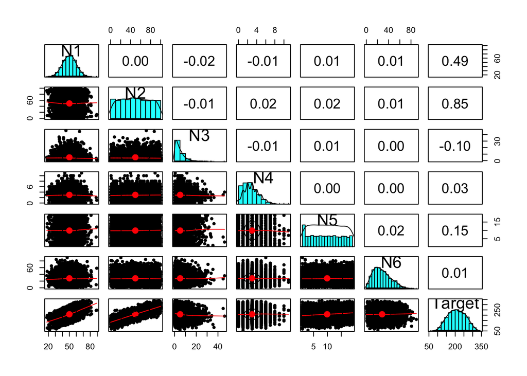

```r
pairs.panels(df[,numeric_features])
```

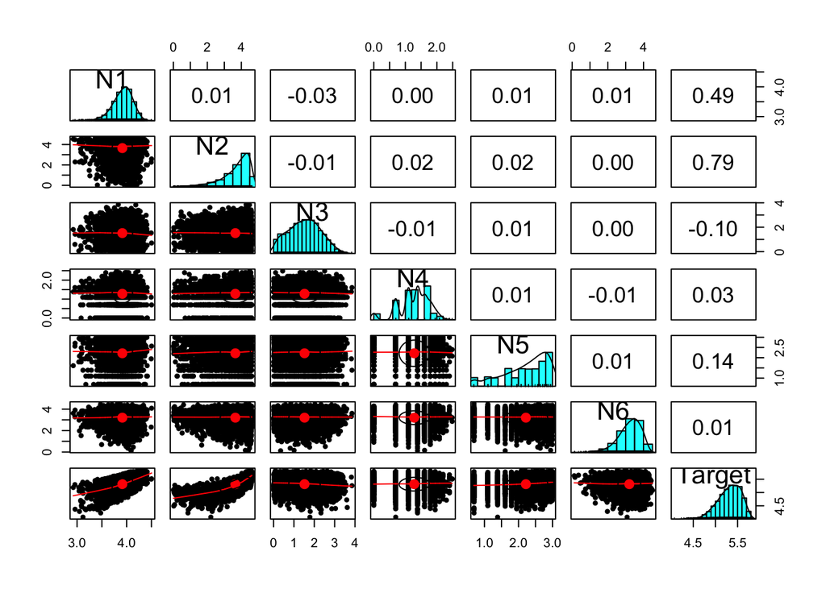

```r
log_df <- log(df[,numeric_features]+1)
pairs.panels(log_df)
```

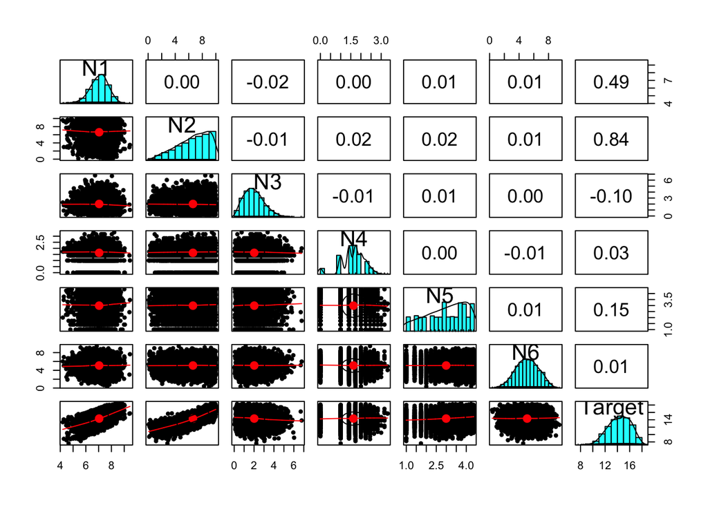

```r
sqrt_df <- sqrt(df[,numeric_features])
pairs.panels(sqrt_df)
```

The distributions of the `N1`, `N2`, and `N5` columns did not improve significantly with any transformation. However, the distribution of `N3` improved the most with a log transformation, while `N6` showed the most improvement with a square root transformation. For `N4`, both log and square root transformations slightly reduced the skewness, although some irregularities remained. Between the two, the square root transformation produced a slightly more favorable distribution.

Now that the most effective transformations for improving the distributions have been identified, we will create a new data frame containing the transformed features to be used for model training.

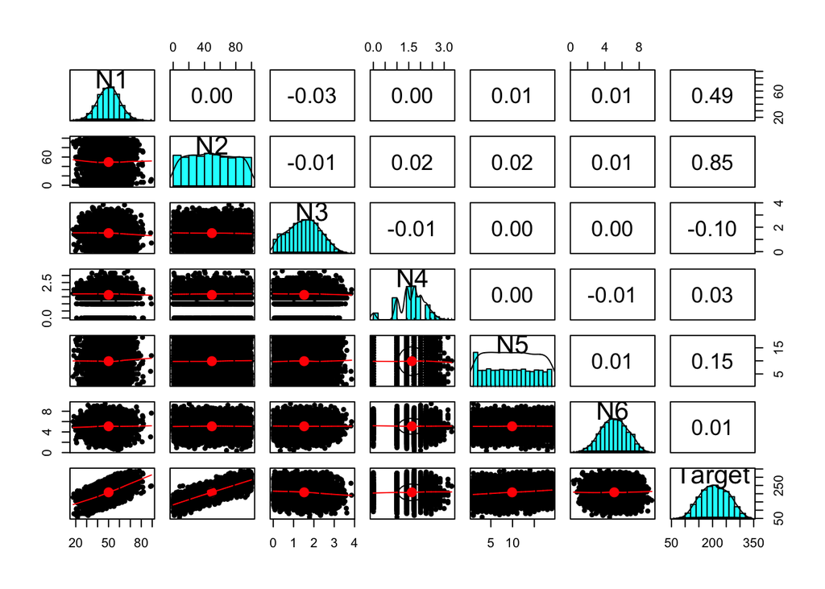

```r
df_transformed <- df %>%
  mutate(N3 = log(N3+1), # log transform
         N4 = sqrt(N4),  # sqrt transform
         N6 = sqrt(N6))  # sqrt transform
pairs.panels(df_transformed[,numeric_features])
```

### Encoding

After transforming the numeric features, we will now encode the categorical features `B1` and `C1.` Since `B1` contains only two categories — “True” and “False” — we will apply binary encoding. We will convert “True” to 1 and “False” to 0, representing the two classes numerically. On the other hand, we will use one-hot encoding for the categorical feature `C1`, which has four ordered levels: “Level1”, “Level2”, “Level3”, and “Level4”. To do so, we will create three new binary columns corresponding to “Level1”, “Level2”, and “Level3”. Each column will have a value of 1 if the data point belongs to that level, and 0 otherwise. The fourth level, “Level4”, will be the baseline category and represented by zeros across all three columns. This approach effectively encodes the categorical variable while preventing redundancy in the regression model.

```r
df_transformed <- df_transformed %>%
  mutate(B1 = ifelse(B1 == "True", 1, 0),  # Binary
         Level1 = ifelse(C1 == "Level1", 1, 0),  # One hot
         Level2 = ifelse(C1 == "Level2", 1, 0),  # one hot
         Level3 = ifelse(C1 == "Level3", 1, 0)) %>%   # one hot
  select(-C1)  # remove levelx column (not needed for linear regression)
```

### Split Data

```r
set.seed(2025)

# create training subset 80%
train_index <- sample(x = 1:nrow(df_transformed),
                     size = (round(nrow(df_transformed)*0.8,0)),
                     replace = F)
train_df <- df_transformed[train_index,]

# save test set
test_df <- df_transformed[-train_index,]

# divide the remaining 80% (training set) into 3 partitions
n.partitions <- 3

## create lists to hold partitions
partitions <- list()
oob <- list()

# generate partitions w/ replacement
for (i in 1:n.partitions){
  sampled_index <- sample(1:nrow(train_df),
                          size = nrow(train_df),
                          replace = T)
  partitions[[i]] <- train_df[sampled_index,]
  oob[[i]] <- train_df[-sampled_index,]
}
```

## Model Training

```r
stepwise_backwards <- function(data, target, threshold){
  # start with previous_many removed
  formula <- paste(target, "~ .")
  model <- lm(as.formula(formula), data = data)

  # Loop until all p-values <= threshold
  repeat {
    p_values <- summary(model)$coefficients[-1, 4]  # exclude intercept
    max_p <- max(p_values)

    if (max_p <= threshold) {
      break
    }

    # Find the predictor with max p-value
    remove_var <- names(which.max(p_values))

    # Update formula by removing this variable
    formula <- paste(formula, " -", remove_var)

    # Refit model
    model <- lm(as.formula(formula), data = data)
  }

  return(model)
}
```

```r
# Create a list to hold the models
models <- list()

# Fit a linear regression model on each training partition
for (i in 1:length(partitions)) {
  train.data <- partitions[[i]]
  model <- stepwise_backwards(train.data, "Target", 0.5 ) # perform stepwise backwards elimination for each model
  models[[i]] <- model
}
```

## Ensemble

```r
lm.ensemble <- function(models, new.data) {

  # Compute RMSE for each model on its training data
  rmses <- sapply(models, function(model) {
    target.act <- model$model$Target
    target.pred <- predict(model, newdata = model$model)
    sqrt(mean((target.act - target.pred)^2))
  })

  # Convert RMSEs to weights: inverse of RMSE (higher weight for lower error)
  inv.rmses <- 1 / rmses
  weights <- inv.rmses / sum(inv.rmses)

  # Predict with each model on new data
  predictions <- sapply(models, function(model) {
    predict(model, newdata = new.data)
  })

  # Ensure predictions are in matrix form
  if (is.vector(predictions)) {
    predictions <- matrix(predictions, nrow = 1)
  }

  # Apply weights to compute weighted average prediction
  weighted.preds <- predictions %*% weights
  as.vector(weighted.preds)
}
```

## Evaluation

We will use the ensemble model to generate predictions on the test set and evaluate its performance. This will allow us to assess how well the ensemble generalizes to unseen data.

```r
test_predicted <- lm.ensemble(models, test_df)
```

To evaluate the prediction model, we will use RMSE to see how far off the predictions are on average and $\text{R}^2$ to see how much variation can be explained by the ensemble.

```r
actual <- test_df$Target

# RMSE and r2 calculations
ensemble_RMSE <- round(sqrt(mean((actual - test_predicted)^2)),2)
ensemble_r2 <- round(1 - (sum((actual-test_predicted)^2)/sum((actual-mean(actual))^2)),2)

# save in df for display
ensemble_eval <- data.frame(RMSE = ensemble_RMSE,
                            Rsquared = ensemble_r2)
kable(ensemble_eval, caption = "Ensemble Evaluation")%>%
  kable_styling()
```

Ensemble Evaluation

| RMSE | Rsquared |
| --- | --- |
| 5.25 | 0.99 |

## Model Validation

Using the ensemble model, we will generate predictions for the target variable in the validation set and calculate the RMSE to evaluate the model’s predictive accuracy. Before making predictions, we will preprocess the validation data in the same way as the training set to ensure consistency in feature scaling, encoding, and transformations.

```r
val_url <- "https://s3.us-east-2.amazonaws.com/artificium.us/datasets/synth-data-validation-500.csv"
val_df <- read.csv(val_url, stringsAsFactors = F, header = T)
```

### Data Preprocessing

```r
# remove ID
train.val_df <- val_df %>% select(-X)

# transform numeric columns
train.val_df <- train.val_df %>%
  mutate(N3 = log(N3+1),
         N4 = sqrt(N4),
         N6 = sqrt(N6))

# encode categorical columns
train.val_df <- train.val_df %>%
  mutate(B1 = ifelse(B1 == "True", 1, 0),
         Level1 = ifelse(C1 == "Level1", 1, 0),
         Level2 = ifelse(C1 == "Level2", 1, 0),
         Level3 = ifelse(C1 == "Level3", 1, 0)) %>%
  select(-C1)
```

### Prediction

```r
val_predicted <- lm.ensemble(models, train.val_df)
```

### Evaluation

```r
val_actual <- train.val_df$Target
val_RMSE <- round(sqrt(mean((val_actual - val_predicted)^2)),2)
```

**RMSE:** *5.39*

This low RMSE indicates that the ensemble model maintained strong predictive performance on the validation data.